# week4-3.EDA_3Hypothesis validation

### 1. 마을의 범죄율에 가장 큰 영향을 미치는 faature는 무엇일까?

#### Attribute Information

- Input features in order:
- 1) CRIM: per capita crime rate by town
- 2) ZN: proportion of residential land zoned for lots over 25,000 sq.ft.
- 3) INDUS: proportion of non-retail business acres per town
- 4) CHAS: Charles River dummy variable (1 if tract bounds river; 0 otherwise)
- 5) NOX: nitric oxides concentration (parts per 10 million) [parts/10M]
- 6) RM: average number of rooms per dwelling
- 7) AGE: proportion of owner-occupied units built prior to 1940
- 8) DIS: weighted distances to five Boston employment centres
- 9) RAD: index of accessibility to radial highways
- 10) TAX: full-value property-tax rate per $10,000 [$/10k]
- 11) PTRATIO: pupil-teacher ratio by town
- 12) B: The result of the equation B=1000(Bk - 0.63)^2 where Bk is the proportion of blacks by town
- 13) LSTAT: % lower status of the population
- Output variable:
- 1) MEDV: Median value of owner-occupied homes in $1000's [k$]
- 특성을 순서대로 입력하십시오.
- 1) CRIM: 마을별 1인당 범죄율
- 2) ZN: 25,000sq.ft 이상의 부지로 구획된 주거용 토지의 비율.
- 3) INDUS: 도시당 비소매 비즈니스 에이커 비율
- 4) CHAS: Charles River 더미 변수(도로 경계 강인 경우 1, 그렇지 않은 경우 0)
- 5) NOX: 산화질소 농도(1천만분의 1) [parts/10M]
- 6 ) RM: 주택당 평균 방 수
- 7) AGE: 1940년 이전에 건축된 자가 소유 단위의 비율
- 8) DIS: 5개의 보스턴 고용 센터까지의 가중 거리
- 9) RAD: 방사형 고속도로에 대한 접근성 지수
- 10) TAX: 전체 $10,000당 가치 재산세율 [$/10k]
- 11) PTRATIO: 도시별 학생-교사 비율
- 12) B: 방정식 B=1000(Bk - 0.63)^2의 결과 여기서 Bk는 마을별 흑인 비율
- 13) LSTAT: 인구의 낮은 지위 %
- 출력 변수:
- 1) MEDV: $1000의 소유자가 점유한 주택의 중앙값 [k$]

### 1. 마을의 범죄율에 가장 큰 영향을 미치는 faature는 무엇일까?(가설)

- 3) INDUS: 도시당 비소매 비즈니스 에이커 비율
- 13) LSTAT: 인구의 낮은 지위 %
- 5) NOX: 산화질소 농도(1천만분의 1) [parts/10M]
- 6 ) RM: 주택당 평균 방 수
- 7) AGE: 1940년 이전에 건축된 자가 소유 단위의 비율
- 12) B: 방정식 B=1000(Bk - 0.63)^2의 결과 여기서 Bk는 마을별 흑인 비율
- 2) ZN: 25,000sq.ft 이상의 부지로 구획된 주거용 토지의 비율.
- 8) DIS: 5개의 보스턴 고용 센터까지의 가중 거리
- *결론: 양의 상관관계; LSTAT, AGE, NOX

  ```
     음의 상관관계;  DIS, RM, B
     상관관계없음. ; INDUS, ZN
  ```

```python
import pandas as pd
import numpy as np
import seaborn as sns
import matplotlib.pyplot as plt
```

```python
boston_df = pd.read_csv("./boston.csv")
#boston_df
```

- 3) INDUS: 도시당 비소매 비즈니스 에이커 비율

```python
# 반올림
boston_df['INDUS'] = boston_df['INDUS'].round()
boston_df[['INDUS', 'CRIM']].groupby(['INDUS']).count()
```

| INDUS | CRIM |
| --- | --- |
| 0.0 | 1 |
| 1.0 | 9 |
| 2.0 | 34 |
| 3.0 | 31 |
| 4.0 | 32 |
| 5.0 | 30 |
| 6.0 | 49 |
| 7.0 | 24 |
| 8.0 | 29 |
| 9.0 | 11 |
| 10.0 | 29 |
| 11.0 | 15 |
| 12.0 | 5 |
| 13.0 | 6 |
| 14.0 | 9 |
| 15.0 | 3 |
| 18.0 | 132 |
| 20.0 | 30 |
| 22.0 | 15 |
| 26.0 | 7 |
| 28.0 | 5 |

```python
boston_df[['INDUS', 'CRIM']].groupby(['INDUS']).sum()
```

| INDUS | CRIM |
| --- | --- |
| 0.0 | 0.01381 |
| 1.0 | 0.22288 |
| 2.0 | 1.70247 |
| 3.0 | 2.00354 |
| 4.0 | 8.65183 |
| 5.0 | 2.21787 |
| 6.0 | 11.87781 |
| 7.0 | 4.61838 |
| 8.0 | 22.26872 |
| 9.0 | 1.77752 |
| 10.0 | 10.01206 |
| 11.0 | 3.11925 |
| 12.0 | 0.32566 |
| 13.0 | 0.50301 |
| 14.0 | 0.82938 |
| 15.0 | 0.11372 |
| 18.0 | 1684.22640 |
| 20.0 | 63.31951 |
| 22.0 | 8.84148 |
| 26.0 | 1.03887 |
| 28.0 | 0.75875 |

```python
boston_df[['INDUS', 'CRIM']].groupby(['INDUS']).mean()
```

| INDUS | CRIM |
| --- | --- |
| 0.0 | 0.013810 |
| 1.0 | 0.024764 |
| 2.0 | 0.050073 |
| 3.0 | 0.064630 |
| 4.0 | 0.270370 |
| 5.0 | 0.073929 |
| 6.0 | 0.242404 |
| 7.0 | 0.192433 |
| 8.0 | 0.767887 |
| 9.0 | 0.161593 |
| 10.0 | 0.345243 |
| 11.0 | 0.207950 |
| 12.0 | 0.065132 |
| 13.0 | 0.083835 |
| 14.0 | 0.092153 |
| 15.0 | 0.037907 |
| 18.0 | 12.759291 |
| 20.0 | 2.110650 |
| 22.0 | 0.589432 |
| 26.0 | 0.148410 |
| 28.0 | 0.151750 |

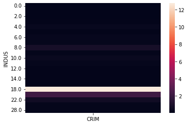

```python
sns.heatmap(boston_df[['INDUS', 'CRIM']].groupby(['INDUS']).mean())
## 비소매에이커비율과 범죄율은 연관관계가 부족하지만, 특정임계값은 존재한다.
```

- 13) LSTAT: 인구의 낮은 지위 %

```python
# 반올림
boston_df['LSTAT'] = boston_df['LSTAT'].round()
boston_df[['LSTAT', 'CRIM']].groupby(['LSTAT']).count()
```

| LSTAT | CRIM |
| --- | --- |
| 2.0 | 4 |
| 3.0 | 15 |
| 4.0 | 24 |
| 5.0 | 35 |
| 6.0 | 30 |
| 7.0 | 34 |
| 8.0 | 30 |
| 9.0 | 26 |
| 10.0 | 39 |
| 11.0 | 20 |
| 12.0 | 24 |
| 13.0 | 28 |
| 14.0 | 21 |
| 15.0 | 23 |
| 16.0 | 20 |
| 17.0 | 20 |
| 18.0 | 22 |
| 19.0 | 11 |
| 20.0 | 11 |
| 21.0 | 11 |
| 22.0 | 3 |
| 23.0 | 9 |
| 24.0 | 10 |
| 25.0 | 3 |
| 26.0 | 5 |
| 27.0 | 5 |
| 28.0 | 4 |
| 29.0 | 2 |
| 30.0 | 5 |
| 31.0 | 5 |
| 32.0 | 1 |
| 34.0 | 3 |
| 35.0 | 1 |
| 37.0 | 1 |
| 38.0 | 1 |

```python
boston_df[['LSTAT', 'CRIM']].groupby(['LSTAT']).sum()
```

| LSTAT | CRIM |
| --- | --- |
| 2.0 | 3.90601 |
| 3.0 | 14.27606 |
| 4.0 | 10.41696 |
| 5.0 | 9.26484 |
| 6.0 | 6.62731 |
| 7.0 | 17.02632 |
| 8.0 | 15.56210 |
| 9.0 | 10.75473 |
| 10.0 | 82.27576 |
| 11.0 | 27.88463 |
| 12.0 | 36.04065 |
| 13.0 | 78.80220 |
| 14.0 | 38.45355 |
| 15.0 | 113.75527 |
| 16.0 | 72.00265 |
| 17.0 | 157.77885 |
| 18.0 | 95.64789 |
| 19.0 | 49.48901 |
| 20.0 | 122.01235 |
| 21.0 | 130.78958 |
| 22.0 | 47.28491 |
| 23.0 | 144.90527 |
| 24.0 | 88.75168 |
| 25.0 | 23.16626 |
| 26.0 | 49.09059 |
| 27.0 | 96.22430 |
| 28.0 | 30.49212 |
| 29.0 | 20.86434 |
| 30.0 | 12.99342 |
| 31.0 | 89.83607 |
| 32.0 | 22.59710 |
| 34.0 | 34.11774 |
| 35.0 | 11.10810 |
| 37.0 | 45.74610 |
| 38.0 | 18.49820 |

```python
boston_df[['LSTAT', 'CRIM']].groupby(['LSTAT']).mean()
```

| LSTAT | CRIM |
| --- | --- |
| 2.0 | 0.976502 |
| 3.0 | 0.951737 |
| 4.0 | 0.434040 |
| 5.0 | 0.264710 |
| 6.0 | 0.220910 |
| 7.0 | 0.500774 |
| 8.0 | 0.518737 |
| 9.0 | 0.413643 |
| 10.0 | 2.109635 |
| 11.0 | 1.394232 |
| 12.0 | 1.501694 |
| 13.0 | 2.814364 |
| 14.0 | 1.831121 |
| 15.0 | 4.945881 |
| 16.0 | 3.600132 |
| 17.0 | 7.888943 |
| 18.0 | 4.347631 |
| 19.0 | 4.499001 |
| 20.0 | 11.092032 |
| 21.0 | 11.889962 |
| 22.0 | 15.761637 |
| 23.0 | 16.100586 |
| 24.0 | 8.875168 |
| 25.0 | 7.722087 |
| 26.0 | 9.818118 |
| 27.0 | 19.244860 |
| 28.0 | 7.623030 |
| 29.0 | 10.432170 |
| 30.0 | 2.598684 |
| 31.0 | 17.967214 |
| 32.0 | 22.597100 |
| 34.0 | 11.372580 |
| 35.0 | 11.108100 |
| 37.0 | 45.746100 |
| 38.0 | 18.498200 |

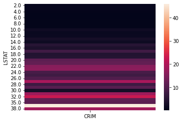

```python
sns.heatmap(boston_df[['LSTAT', 'CRIM']].groupby(['LSTAT']).mean())
# CRIM 상관관계가 높다.
```

- 7) AGE: 1940년 이전에 건축된 자가 소유 단위의 비율

```python
# 반올림
boston_df['AGE'] = boston_df['AGE'].round()
boston_df[['AGE', 'CRIM']].groupby(['AGE']).count()
```

| AGE | CRIM |
| --- | --- |
| 3.0 | 1 |
| 6.0 | 3 |
| 7.0 | 3 |
| 8.0 | 3 |
| 9.0 | 1 |
| ... | ... |
| 96.0 | 15 |
| 97.0 | 17 |
| 98.0 | 19 |
| 99.0 | 10 |
| 100.0 | 43 |

91 rows × 1 columns

```python
boston_df[['AGE', 'CRIM']].groupby(['AGE']).sum()
```

| AGE | CRIM |
| --- | --- |
| 3.0 | 0.12744 |
| 6.0 | 0.43371 |
| 7.0 | 0.31197 |
| 8.0 | 0.58815 |
| 9.0 | 0.21409 |
| ... | ... |
| 96.0 | 82.70981 |
| 97.0 | 104.51176 |
| 98.0 | 76.19960 |
| 99.0 | 68.58681 |
| 100.0 | 647.36046 |

91 rows × 1 columns

```python
boston_df[['AGE', 'CRIM']].groupby(['AGE']).mean()
```

| AGE | CRIM |
| --- | --- |
| 3.0 | 0.127440 |
| 6.0 | 0.144570 |
| 7.0 | 0.103990 |
| 8.0 | 0.196050 |
| 9.0 | 0.214090 |
| ... | ... |
| 96.0 | 5.513987 |
| 97.0 | 6.147751 |
| 98.0 | 4.010505 |
| 99.0 | 6.858681 |
| 100.0 | 15.054894 |

91 rows × 1 columns

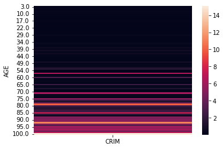

```python
sns.heatmap(boston_df[['AGE', 'CRIM']].groupby(['AGE']).mean())
# 범죄율과 상관관계가 있다.
```

- 5) NOX: 산화질소 농도(1천만분의 1) [parts/10M]

```python
# 반올림
boston_df['NOX'] = boston_df['NOX'].round()
boston_df[['NOX', 'CRIM']].groupby(['NOX']).count()
```

| NOX | CRIM |
| --- | --- |
| 0.0 | 192 |
| 1.0 | 314 |